# Final Project: Analyzing Airplane Crashes and Deaths (1970 - 2025)

Author

Shruti Oak

Published

August 15, 2025

## Setup

```r
# for data wrangling
library(dplyr)
library(tidyr)
library(lubridate)
library(readr)
library(forcats)
library(stringr)
library(here)

#for plotting over time
library(ggplot2)
```

## Project Introduction

More often than not, air travel is deemed to be one of the safest and fastest modes of travelling. However, there is data which proves that this was not always the case. Advancements in technology, safety regulations, and higher aviation standards have led to changes in airplane crashes and death trends.

This project analyzes two main research questions:

1. **How have the number of airplane crash fatalities changed from 1970 to 2025?**
2. **Do years with higher number of plane crashes have a higher number of death toll?**

The aim of this project is to discover patterns in crash and fatality rates, in order to correctly increase safety measures related to air travel.

## Dataset

```r
airplaneCrash <- read_csv("data/Airplane Crashses and Deaths (1970-2025).csv",
                          show_col_types = FALSE)
head(airplaneCrash)
```

```
# A tibble: 6 × 3
   Year Deaths Crashes
  <dbl>  <dbl>   <dbl>
1  1970   2226     298
2  1971   2228     271
3  1972   3346     344
4  1973   2814     333
5  1974   2621     270
6  1975   1856     316
```

```r
dim(airplaneCrash)
```

```
[1] 56  3
```

```r
newFunc <- function(n) {
  output <- list(
    range = range(n, na.rm = TRUE),
    mean = mean(n, na.rm = TRUE),
    standardDev = sd(n, na.rm = TRUE),
    numOfNA = sum(is.na(n)),
    numUniqueVals = n_distinct(n, na.rm = TRUE))

  return(output)
}

newFunc(airplaneCrash$Crashes)
```

```
$range
[1]  61 356

$mean
[1] 217.5357

$standardDev
[1] 73.51808

$numOfNA
[1] 0

$numUniqueVals
[1] 51
```

```r
newFunc(airplaneCrash$Deaths)
```

```
$range
[1]  178 3346

$mean
[1] 1545.786

$standardDev
[1] 781.6081

$numOfNA
[1] 0

$numUniqueVals
[1] 56
```

The dataset being analyzed includes the number of airplane crashes and deaths from the year 1970 to 2025. The data used has been taken from Kaggle, and it is a tidy dataset. It includes three variables:

1. Year (represents the year in which the plane crashed and deaths occurred)
2. Deaths (represents the number of fatalities caused by the plane crash)
3. Crashes (represents the total number of plane accidents)

The dataset includes a total of 56 rows representing each year starting from 1970 to 2025. The unit of observation for this case is a year, wherein each year describes the number of deaths and crashes that occurred in that year. The number of fatalities over the years range from 178 deaths being the lowest, to 3346 deaths being the highest, with the mean number of deaths being 1545.79, and the standard deviation being 781.61. The number of crashes range from 61 crashes to 356 crashes, with a mean number of crashes being 217.54, and the standard deviation being 73.52. There are no missing values in any of the three variables.

## Change in Airplane Crashes and Fatalities from 1970 to 2025

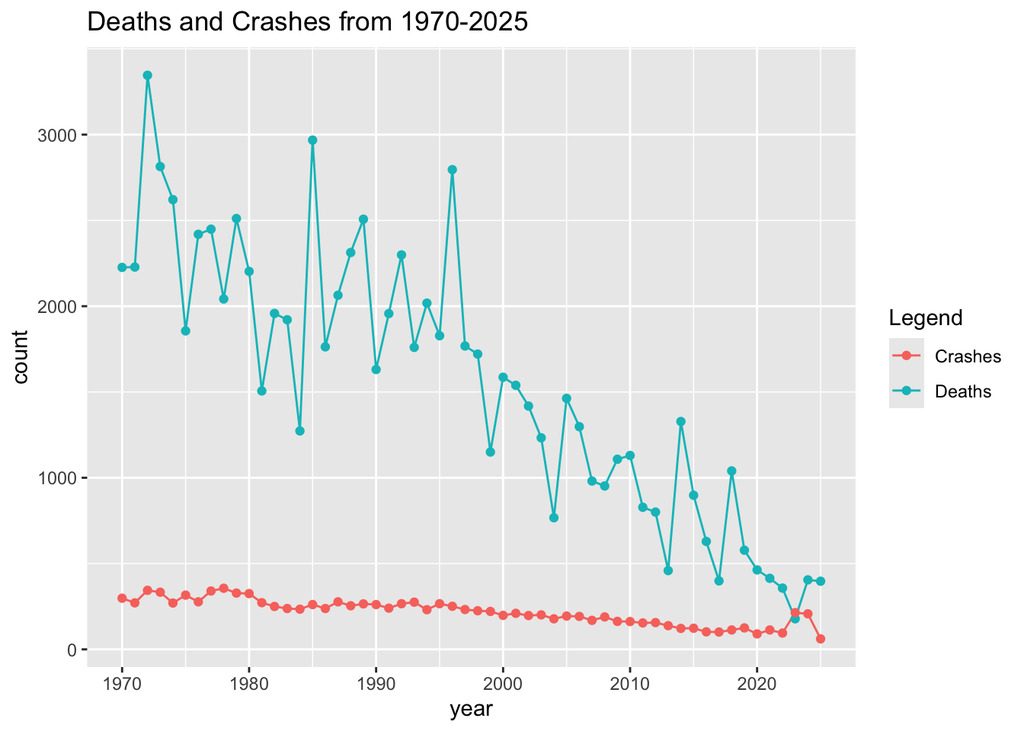

```r
newAirplaneRecord <- airplaneCrash |>
  pivot_longer(cols = c(Deaths, Crashes),
               names_to = "Legend",
               values_to = "Count")

newAirplaneRecord |>
  ggplot(aes(x = Year, y = Count, color = Legend)) +
  geom_line() +
  geom_point() +
  labs(title = "Deaths and Crashes from 1970-2025",
       x = "year",
       y = "count")
```

In order to achieve this analysis, data was reshaped into a “longer” format. This allowed for the number of deaths and crashes to be plotted onto the same graph, and create a comparison between the two trends over time.

## Relation Between Number of Plane Crashes and Death Toll

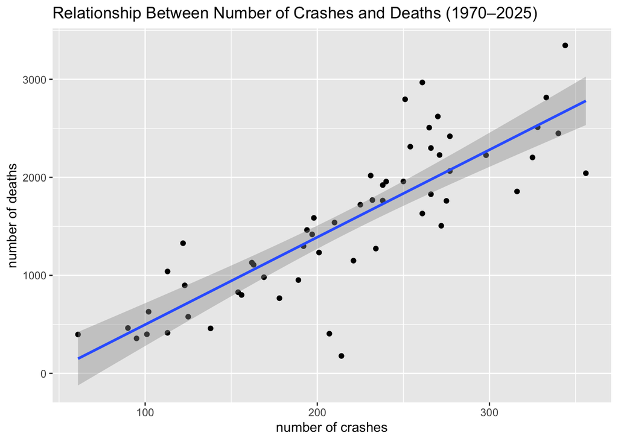

```r
airplaneCrash |>
  ggplot(aes(x = Crashes, y = Deaths)) +
  geom_point() +
  geom_smooth(method = "lm", formula = y ~ x) +
  labs(title = "Relationship Between Number of Crashes and Deaths (1970–2025)",
       x = "number of crashes",
       y = "number of deaths")
```

The scatter plot above shows the relation between the number of deaths and crashes wherein the points in the graph represent each year from 1970 to 2025, and the line of best fit represents the slope indicating the high number of crashes to deaths relation. There are certain outliers, which represents scenarios wherein the death toll is higher for a lower amount of crashes.

Whenever such outliers are seen, it could be assumed that when the death toll is higher, there could have been a commercial flight that crashed. Therefore, one crash would lead to significantly more deaths, as compared to if there were multiple small aircraft crashes. The scatter plot shows that although there is a correlation between the number of crashes and deaths, there are always underlying exceptions that need to be analyzed to fully understand the dataset.

## Conclusion

The analysis of this dataset demonstrates that the aviation department has made a lot of progress since 1970, which could be seen through the reduced number of deaths from airplane crashes, and the overall low levels of airplane crashes. This dataset includes a lot of critical information which is needed to make an accurate analysis, and does not really need any additional information. However, if the analysis requires there to be a more specific search, then it could possibly be a good idea to look into which airlines or which countries had the most crashes take place in a given year. This would be useful for a different / more specific type of research question, but for our research questions, the dataset used is a perfect fit.

## Bibliography

Kemwal, Madhulika. “Flight Crashes and Deaths (1970-2025).” Kaggle, 15 June 2025, www.kaggle.com/datasets/madhulikakemwal/flight-crashes-and-deaths-1970-2025.

Long, James (JD), and Paul Teetor. “R Cookbook, 2nd Edition.” R Cookbook, 2nd Edition, 26 Sept. 2019, rc2e.com/

R Core Team. R: A Language and Environment for Statistical Computing. Version 4.4.1, R Foundation for Statistical Computing, 2025, https://www.R-project.org/